# Homework 4

DATS 6101 · Fall 2026

Sam Nicholes

2026-10-04

https://www.smajhi.com/DATS-6101/homework/hw4.html#ai-disclosure-required

```r
library(nycflights13)
library(tidyverse)
data(flights)

d <- flights[complete.cases(flights), ] # data set of complete rows stored as d

# A day is a calendar date built from year, month and day.
d <- d %>% dplyr::mutate(date = lubridate::make_date(year, month, day))

population <- d$arr_delay
mu <- mean(population)
sigma <- sd(population)
```

Confirm observation count for for `d`: 327346

Population defined as `d$arr_delay`

Mu: 6.9

Sigma: 44.63

# Part 1 · The theorem is about the mean (12 points)

## (1a) How skewed is arr_delay

```r
skewness <- function(x) mean((x - mean(x))^3) / sd(x)^3 # define skew function

pop_skew <- skewness(population)
```

Skewness of `arr_delay`: 3.72.

## (1b) The sampling distribution at n = 5, 30, 200

```r
# Define sample sizes and replicates
n5 <- 5
n30 <- 30
n200 <- 200
reps <- 5000

# Define sample function for simulation replicability
# n = sample size
# reps = number of replications to perform for simulation
# pop = population to sample from
sim_means <- function(n, reps, pop) {
  set.seed(6101)
  replicate(reps, mean(sample(pop, n, replace = TRUE)))
}

# 5000 means of sample size, n
mean_5 <- sim_means(n5, reps, population)
mean_30 <- sim_means(n30, reps, population)
mean_200 <- sim_means(n200, reps, population)

# all means of 5000 of sample size, n
all_means_5000 <- tibble(
  n = rep(c(n5, n30, n200), each = reps),
  xbar = c(mean_5, mean_30, mean_200))
head(all_means_5000, 5)
```

```
## # A tibble: 5 × 2
##       n  xbar
##   <dbl> <dbl>
## 1     5  23.8
## 2     5  22.6
## 3     5  27.2
## 4     5 -11.4
## 5     5 -11.4
```

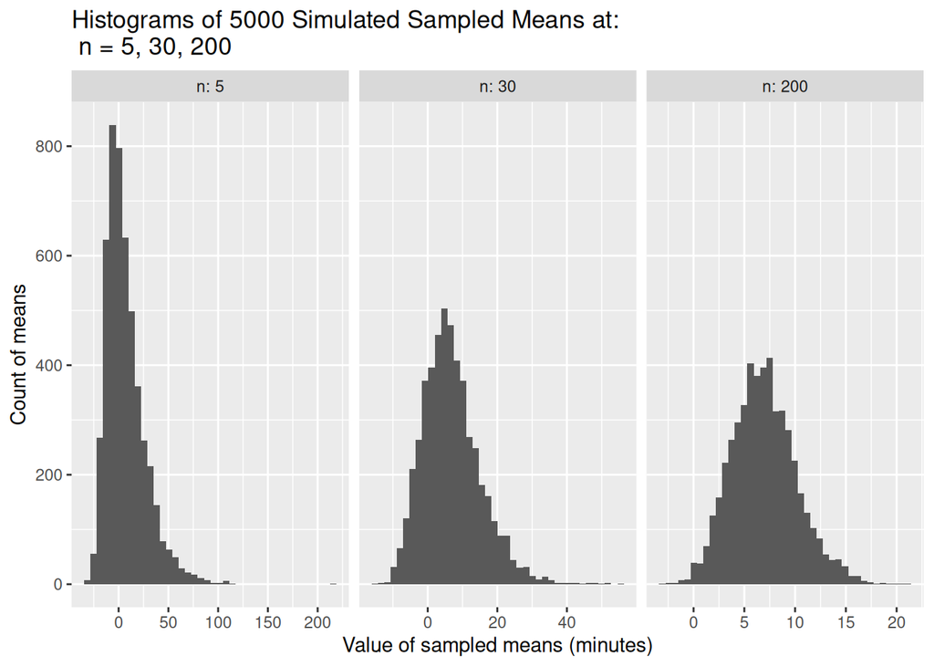

```r
# grand means and associated stats
grand_stats <- tibble(
  n = c(n5, n30, n200),
  means = c(mean(mean_5), mean(mean_30), mean(mean_200)), # grand means at sample size n
  sd = c(sd(mean_5), sd(mean_30), sd(mean_200)), # sd of means at sample size n
  skew = c(skewness(mean_5), skewness(mean_30), skewness(mean_200)) # skew of means at sample size n
)

# 3 histograms
ggplot(all_means_5000, aes(xbar)) +
  geom_histogram(bins = 40) +
  facet_wrap(~ n, nrow = 1, scales = "free_x", labeller = label_both) +
  labs(title = "Histograms of 5000 Simulated Sampled Means at: \n n = 5, 30, 200",
       x = "Value of sampled means (minutes)",
       y = "Count of means")
```

## (1c) What became Normal, and what did not

The skewness for each sample size (5, 30, 200) are: 1.5, 0.82, and 0.35, respectively. Sample size, n = 5, is the most skewed, resembling the population from which it was sampled (3.72). As sample size increases, the distribution converges on normality, where n = 200 is closest to normality.

# Part 2 · Counting the coverage (20 points)

## (2a) Coverage at three sample sizes

```r
n10 <- 10
reps2 <- 2000


sim_t_stats <- function(n, reps, pop) {
  set.seed(6101)
  out <- replicate(reps, { # specify replicates
    x <- sample(pop, n, replace = TRUE) # draw samples of size n
    c(xbar = mean(x), s = sd(x)) # calculate mean and sd of each sample of size n
  })
  tibble(xbar = out["xbar", ], s = out["s", ]) # output as tibble
}

sim_2k_means10  <- sim_t_stats(n10,  reps2, population)
sim_2k_means30  <- sim_t_stats(n30,  reps2, population)
sim_2k_means200 <- sim_t_stats(n200, reps2, population)


# Function to get confidence intervals for each sample and if sample CI includes:
# stats is the tibble from sim_t_stats with mean and sd
# n is sample of size n
# mu is population mean
t_coverage <- function(stats, n, mu) {
  half <- qt(0.975, n - 1) * stats$s / sqrt(n) # calculate half of confidence interval for each sample of size n
  mean(stats$xbar - half <= mu & mu <= stats$xbar + half) # proportions of confidence intervals that contain mu
}

# Coverage for each sample of size n
cov_10  <- t_coverage(sim_2k_means10,  n10,  mu)
cov_30  <- t_coverage(sim_2k_means30,  n30,  mu)
cov_200 <- t_coverage(sim_2k_means200, n200, mu)
cov_10
```

```
## [1] 0.859
```

```r
cov_30
```

```
## [1] 0.894
```

```r
cov_200
```

```
## [1] 0.9375
```

For each sample size (n = 10, 30, 200) at 2000 replications, the respective coverages are:

n = 10: 0.859

n = 30: 0.894

n = 200: 0.9375

## (2b) The misses, and which side they are on

```r
# Function to get proportion of sample CIs where CI is below MU
# stats is the tibble from sim_t_stats with mean and sd
# n is sample of size n
# mu is population mean
t_miss_summary <- function(stats, n, mu) {
  margin <- qt(0.975, n - 1) * stats$s / sqrt(n)  # half-width of each interval
  lower  <- stats$xbar - margin
  upper  <- stats$xbar + margin

  covered    <- lower <= mu & mu <= upper # is mu included in CI
  miss_below <- upper < mu      # whole interval left of mu
  miss_above <- lower > mu      # whole interval right of mu

  tibble(
    n           = n,
    coverage    = mean(covered), # proportion of samples that include mu
    n_miss      = sum(!covered), # proportion of samples that exclude mu
    share_below = sum(miss_below) / sum(!covered) # proportion of samples where CI is below MU
  )
}

miss_tbl <- bind_rows(
  t_miss_summary(sim_2k_means10,  n10,  mu),
  t_miss_summary(sim_2k_means30,  n30,  mu),
  t_miss_summary(sim_2k_means200, n200, mu)
)

miss_tbl
```

```
## # A tibble: 3 × 4
##       n coverage n_miss share_below
##   <dbl>    <dbl>  <int>       <dbl>
## 1    10    0.859    282       0.996
## 2    30    0.894    212       0.981
## 3   200    0.938    125       0.816
```

None of the given sample sizes achieved 95% coverage. All fell below, with n = 200 coming closest at 0.9375. For each sample CI, the majority of CIs that did not include mu, were below mu, because the the extreme values from a right-skewed distribution pull mu to the right.

## (2c) For the colleague with ten flights

```r
# Function to get confidence intervals for each sample and if sample CI includes:
# stats is the tibble from sim_t_stats with mean and sd
# n is sample of size n
# mu is population mean
t_99_coverage <- function(stats, n, mu) {
  half <- qt(0.995, n - 1) * stats$s / sqrt(n) # calculate half of confidence interval for each sample of size n
  mean(stats$xbar - half <= mu & mu <= stats$xbar + half) # proportions of confidence intervals that contain mu
}

# Coverage for each sample of size n
cov_10_99  <- t_99_coverage(sim_2k_means10,  n10,  mu)
cov_30_99  <- t_99_coverage(sim_2k_means30,  n30,  mu)
cov_200_99 <- t_99_coverage(sim_2k_means200, n200, mu)
cov_10_99
```

```
## [1] 0.93
```

```r
cov_30_99
```

```
## [1] 0.95
```

```r
cov_200_99
```

```
## [1] 0.98
```

Increasing the confidence level will widen the confidence interval, but precision is the cost in estimating mu from widening the interval. For example, at 95% confidence the coverage is as stated previously: 0.86, 0.89, 0.94 (n = 10, 30 200). When confidence is increased, the proportion of intervals that contain mu increases: 0.93, 0.95, 0.98 (n = 10, 30, 200).

# Part 3 · What the t fixes (10 points)

## (3a) The same intervals with 1.96

```r
# Function to get confidence intervals using qnorm() for each sample and if sample CI:
# stats is the tibble from sim_t_stats with mean and sd
# n is sample of size n
# mu is population mean
norm_coverage <- function(stats, n, mu) {
  half <- qnorm(0.975) * stats$s / sqrt(n) # calculate half of confidence interval for each sample of size n
  mean(stats$xbar - half <= mu & mu <= stats$xbar + half) # proportions of confidence intervals that contain mu
}

cov_10
```

```
## [1] 0.859
```

```r
cov_30
```

```
## [1] 0.894
```

```r
cov_200
```

```
## [1] 0.9375
```

```r
norm_cov_10 <- norm_coverage(sim_2k_means10,  n10,  mu)
norm_cov_10
```

```
## [1] 0.8225
```

```r
norm_cov_30 <- norm_coverage(sim_2k_means30,  n30,  mu)
norm_cov_30
```

```
## [1] 0.886
```

```r
norm_cov_200 <- norm_coverage(sim_2k_means200,  n200,  mu)
norm_cov_200
```

```
## [1] 0.936
```

## (3b) What the t corrects for, and what it cannot

The t-distribution corrects for a narrower confidence interval that would be generated by using the normal distribution. Howeever, the t distribution can’t correct for data that are skewed (as in this example), if anything the assumption of normality is stricter with a t-distribution but is robust against deviation from normality as n grows which is also why CIs generated for n = 200 agree more at this sample size.

# Part 4 · The interval that is not about the population (20 points)

## (4a) One whole day, two thousand times

```r
# one row per calendar date: flights that day, mean and sd of arr_delay
day_stats <- d %>%
  group_by(date) %>%
  summarise(n = n(), xbar = mean(arr_delay), s = sd(arr_delay))

set.seed(6101)

# reps2 = 2000 from above
sample_days <- day_stats[sample(nrow(day_stats), reps2, replace = TRUE), ]

ci_days_half    <- qt(0.975, sample_days$n - 1) * sample_days$s / sqrt(sample_days$n)  # half of CI
ci_days_lower   <- sample_days$xbar - ci_days_half # lower CI bound
ci_days_upper   <- sample_days$xbar + ci_days_half # upper CI bound
covered_days <- ci_days_lower <= mu & mu <= ci_days_upper # is mu in interval

avg_flights <- mean(sample_days$n) # average flights per interval
avg_flights
```

```
## [1] 896.5565
```

```r
cov_days     <- mean(covered_days) # share of intervals that contain mu
cov_days
```

```
## [1] 0.113
```

```r
avg_width   <- mean(ci_days_upper - ci_days_lower)   # average width of intervals
avg_width
```

```
## [1] 5.144544
```

Average number of flights per interval: 896.56

Proportion of CIs that include mu: 0.11

Average width of intervals: 5.14

## (4b) The same number of random flights

```r
set.seed(6101)

# one random sample from the whole population for each day-interval's sample size
pop_stats <- sapply(sample_days$n, function(k) { # same number of flights
  x <- sample(population, k, replace = TRUE) # sample from entire population
  c(xbar = mean(x), s = sd(x)) # xbar and sd for each sample
})   # 2 x 2000 matrix: row "xbar" and row "s"

ci_pop_half  <- qt(0.975, sample_days$n - 1) * pop_stats["s", ] / sqrt(sample_days$n) # half width of CI
ci_pop_lower <- pop_stats["xbar", ] - ci_pop_half
ci_pop_upper <- pop_stats["xbar", ] + ci_pop_half
covered_pop  <- ci_pop_lower <= mu & mu <= ci_pop_upper

cov_pop       <- mean(covered_pop)                 # share of intervals that contain mu
avg_width_pop <- mean(ci_pop_upper - ci_pop_lower)


# compare whole day sampling to full population sampling
compare_days <- tibble(
  sampling     = c("One whole day", "Random flights, whole file"),
  avg_flights  = c(mean(sample_days$n), mean(sample_days$n)),
  coverage     = c(cov_days, cov_pop),
  avg_width    = c(avg_width, avg_width_pop)
)
knitr::kable(compare_days, digits = 2)
```

| sampling | avg_flights | coverage | avg_width |
| --- | --- | --- | --- |
| One whole day | 896.56 | 0.11 | 5.14 |
| Random flights, whole file | 896.56 | 0.95 | 5.87 |

```r
se_days <- mean(sample_days$s / sqrt(sample_days$n))  # average SE, day intervals
se_pop  <- mean(pop_stats["s", ] / sqrt(sample_days$n))  # average SE, random samples
```

## (4c) Which step failed

Sampling a whole day lacks independence among flights (step 2 fails in the derivation), so the variance within a day shrinks and the standard error is too small (1.31. The CI is too narrow and centered on a day-specific mean that is often far from mu (the interval is for the day not for mu), so it rarely captures mu (0.11). Widening in the intervals won’t help as a result since the days interval is so far from mu to begin with. Truly independent sampling captured mu in 0.95 of intervals, close to the nominal 95%.

## (4d) The fix, measured

```r
# the 365 daily means (one number per calendar date)
daily_means <- day_stats$xbar
head(daily_means, 10)
```

```
##  [1] 12.6510229 12.6928879  5.7333333 -1.9328194 -1.5258020  4.2364294
##  [7] -4.9473118 -3.2275785 -0.2642777 -5.8988159
```

```r
n16   <- 16


# draw 16 days at random, build the t interval from their 16 means
# (replace = FALSE: 16 distinct days from the 365)
# n = sample size
# reps = replications of simulation
# dm = daily means

sim_day_ci <- function(n, reps, dm) {
  set.seed(6101)
  out <- replicate(reps, {
    x <- sample(dm, n)
    c(xbar = mean(x), s = sd(x))
  })
  tibble(xbar = out["xbar", ], s = out["s", ])
}

day16_stats <- sim_day_ci(n16, reps2, daily_means)

ci16_half  <- qt(0.975, n16 - 1) * day16_stats$s / sqrt(n16)
ci16_lower <- day16_stats$xbar - ci16_half
ci16_upper <- day16_stats$xbar + ci16_half
covered_16 <- ci16_lower <= mu & mu <= ci16_upper

nrow(day16_stats)
```

```
## [1] 2000
```

```r
cov_16        <- mean(covered_16)   # share of intervals that contain mu
cov_16
```

```
## [1] 0.93
```

```r
avg_half_16   <- mean(ci16_half)    # average half-width
avg_half_16
```

```
## [1] 8.830241
```

The coverage from randomly sampling 16 days has substantially improved (0.93, closer to the desired 95% confidence) compared to sampling whole days (0.113).

# Part 5 · An interval for a rare rate (16 points)

## (5a) p, and np at n = 200

```r
# proportion of flights arrive more than 3 hours late
p <- mean(d$arr_delay > 180)
p
```

```
## [1] 0.01173987
```

```r
n200 <- 200

np200 <- n200 * p
np200
```

```
## [1] 2.347974
```

## (5b) The textbook interval

```r
# returns the sample share of flights arriving more than 180 minutes late, one per sample
# n = sample size
# reps = number of replications
# pop = population to sample from

sim_props <- function(n, reps, pop) {
  set.seed(6101)
  replicate(reps, mean(sample(pop, n, replace = TRUE) > 180))
}

phat200 <- sim_props(n200, reps2, population)


se_phat    <- sqrt(phat200 * (1 - phat200) / n200) # SE for proportion
ci_p_lower <- phat200 - 1.96 * se_phat
ci_p_upper <- phat200 + 1.96 * se_phat

covered_p  <- ci_p_lower <= p & p <= ci_p_upper # is p in interval

cov_p      <- mean(covered_p)           # share of intervals containing p
cov_p
```

```
## [1] 0.8995
```

```r
share_none <- mean(phat200 == 0)        # share of samples with no late flight at all
share_none
```

```
## [1] 0.096
```

```r
share_neg  <- mean(ci_p_lower < 0)      # share of intervals with a negative lower bound
share_neg
```

```
## [1] 0.6955
```

## (5c) prop.test

```r
# count of late flights in each sample, recovered from the sample share
k200 <- round(phat200 * n200)

# prop.test interval for every sample
ci_pt <- sapply(k200, function(k) prop.test(k, n200)$conf.int)

ci_pt_lower <- ci_pt[1, ]
ci_pt_upper <- ci_pt[2, ]

covered_pt <- ci_pt_lower <= p & p <= ci_pt_upper
cov_pt     <- mean(covered_pt)   # share of intervals that contain p
cov_pt
```

```
## [1] 0.964
```

```r
cov_ptest <- prop.test(0, 200)$conf.int
cov_ptest
```

```
## [1] 0.00000000 0.02349004
## attr(,"conf.level")
## [1] 0.95
```

```r
cov_ptest[1]
```

```
## [1] 0
```

```r
cov_ptest[2]
```

```
## [1] 0.02349004
```

## (5d) What you would report

Flights that are more than 3 hours late are very rare making the proportion essentially 0, but the interval goes into negative numbers for samples with only a couple of late flights, which doesn’t make any sense given the context. Overall the entirety of the interval is a single point at 0. The function prop.test() is more appropriate for events that are rare, like this one. So when reporting to a manager for the rate, I would use prop.test() to give 0.964 (0, 0.02349)

# Part 6 · The sentence, and what precision costs (12 points)

## (6a) One sample, one interval

```r
set.seed(6101)
one_sample <- sample(population, n200, replace = TRUE)
one_mean <- mean(one_sample)
one_sd <- sd(one_sample)
one_se <- one_sd / sqrt(n200)
one_t <- qt(0.975, n200 - 1)
one_ci <- one_t * one_se
one_ci
```

```
## [1] 5.744946
```

```r
one_lower <- one_mean - one_ci
one_upper <- one_mean + one_ci

one_covered <- one_lower <= mu & mu <= one_upper
one_covered
```

```
## [1] TRUE
```

```r
# Check against built-in functions
# t.test(one_sample)$conf.int
# all.equal(c(one_lower, one_upper), as.numeric(t.test(one_sample)$conf.int))
```

sample mean: 5.24

sample sd: 41.2

Does the one sample of 200 contain mu? 1.

## (6b) The sentence, and two that are wrong

Wrong 1: There is a 95% chance that mu is in the sample interval. This treats mu as having a probability of being in the interval.

Wrong 2: Mu may be found in a given sample interval of 200 flights 95% of the time. This sentence also treats mu has having a probability of being in the interval - that mu moves instead of the sampling interval. And that the probability of finding mu in a single sample of 200 changes.

## (6c) The cost of halving the width

```r
s <- sd(d$arr_delay)

n_1 <- (1.96 * s / 1)^2
n_05 <- (1.96 * s / 0.5)^2
n_1
```

```
## [1] 7652.969
```

```r
n_05
```

```
## [1] 30611.88
```

```r
n_ratio <-n_05 / n_1
```

The ratio between sample sizes of halving the width of the interval is 4. The cost of halving the width is needing a large sample size. We’re requiring greater precision at the same confidence level and need a larger sampler to achieve this.

# AI disclosure

## Prompt log

https://claude.ai/share/b9d2af9d-d7b6-40d3-ae8f-d0a0c8643c1b